# R_bnb

# Quels sont les facteurs qui permettent d’expliquer la différence de prix entre 2 biens?

les données proviennet du site kaggle : https://www.kaggle.com/datasets/thedevastator/airbnb-prices-in-european-cities

```r
data_R_bnb <- na.omit(read.csv("data/data_R_bnb.csv", stringsAsFactors = TRUE, row.names = 1))
summary(data_R_bnb)
```

```
##       lat         prix_semaine                room_type     room_shared
##  Min.   :37.95   Min.   :   39.01   Entire home/apt:16407   False:26142
##  1st Qu.:38.74   1st Qu.:  145.99   Private room   : 9735   True :  186
##  Median :47.46   Median :  210.18   Shared room    :  186
##  Mean   :45.04   Mean   :  270.86
##  3rd Qu.:48.89   3rd Qu.:  313.08
##  Max.   :52.64   Max.   :18545.45
##
##  room_private  person_capacity host_is_superhost     multi
##  False:16593   Min.   :2.000   False:19671       Min.   :0.0000
##  True : 9735   1st Qu.:2.000   True : 6657       1st Qu.:0.0000
##                Median :3.000                     Median :0.0000
##                Mean   :3.121                     Mean   :0.2594
##                3rd Qu.:4.000                     3rd Qu.:1.0000
##                Max.   :6.000                     Max.   :1.0000
##
##       biz         cleanliness_rating guest_satisfaction_overall
##  Min.   :0.0000   Min.   : 2.00      Min.   : 20.0
##  1st Qu.:0.0000   1st Qu.: 9.00      1st Qu.: 90.0
##  Median :0.0000   Median :10.00      Median : 95.0
##  Mean   :0.4493   Mean   : 9.39      Mean   : 92.4
##  3rd Qu.:1.0000   3rd Qu.:10.00      3rd Qu.: 98.0
##  Max.   :1.0000   Max.   :10.00      Max.   :100.0
##
##     bedrooms           dist            metro_dist          attr_index
##  Min.   : 0.000   Min.   : 0.01506   Min.   : 0.003944   Min.   :  16.6
##  1st Qu.: 1.000   1st Qu.: 1.27873   1st Qu.: 0.239550   1st Qu.: 141.4
##  Median : 1.000   Median : 2.47234   Median : 0.404562   Median : 253.9
##  Mean   : 1.115   Mean   : 2.99741   Mean   : 0.655601   Mean   : 309.6
##  3rd Qu.: 1.000   3rd Qu.: 4.04959   3rd Qu.: 0.720588   3rd Qu.: 420.6
##  Max.   :10.000   Max.   :22.61745   Max.   :13.314108   Max.   :4512.6
##
##  attr_index_norm     rest_index      rest_index_norm            pays
##  Min.   :  1.041   Min.   :  21.46   Min.   :  0.667   Italie     :5331
##  1st Qu.:  6.511   1st Qu.: 277.35   1st Qu.: 10.884   Royaume-Uni:4594
##  Median : 11.237   Median : 580.17   Median : 19.595   Portugal   :3878
##  Mean   : 13.233   Mean   : 692.89   Mean   : 25.566   France     :3476
##  3rd Qu.: 17.315   3rd Qu.: 925.28   3rd Qu.: 36.648   Grece      :2901
##  Max.   :100.000   Max.   :5584.77   Max.   :100.000   Hongrie    :1721
##                                                        (Other)    :4427
##   prix_weekend
##  Min.   :   40.18
##  1st Qu.:  150.58
##  Median :  216.46
##  Mean   :  276.33
##  3rd Qu.:  324.36
##  Max.   :13656.36
##
```

On cherche à quantifier l’influence de plusieurs variables explicatives sur le prix des Airbnb. Et plus précisément qu’elles sont celles qui permettent d’expliquer une différence de prix entre la semaine et le weekend. En effet, on observe une différence de prix des biens entre la semaine et le weekend. Cependant on peut observer que cette différence de prix entre la semaine et le week-end n’est pas la même pour tous les biens. Comme le montre le graphique suivant

```r
library(ggplot2)
#prix moyen des airbnb la semaine
semaine <- round(mean(data_R_bnb$prix_semaine), digits = 2 )
#prix moyen des aibrnb le weekend
week_end <- round(mean(data_R_bnb$prix_weekend),2)
data.frame(semaine, week_end)
```

```
##   semaine week_end
## 1  270.86   276.33
```

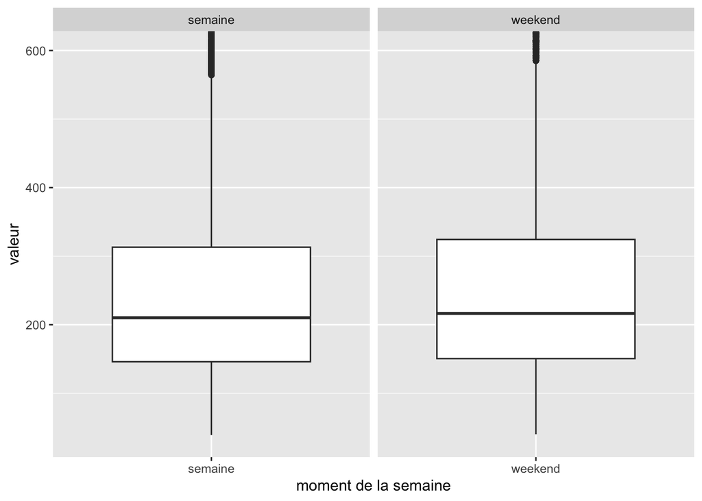

```r
# Chargement des packages nécessaires
library(ggplot2)
library(tidyr)

# Exemple de données
data <- data.frame(
  semaine = data_R_bnb$prix_semaine,
  weekend = data_R_bnb$prix_weekend
)

# Transformation des données en format long
data_long <- gather(data, key = "prix", value = "valeur")

# Création du boxplot en facettes
ggplot(data_long, aes(x = prix, y = valeur)) +
  geom_boxplot() +
  facet_grid(. ~ prix, scales = "free_x")+
    coord_cartesian(ylim = c(35, 600))+
    xlab("moment de la semaine")
```

```r
rm(data, data_long)
```

Sur le Graphique précédent il est clair que les Airbnb sont plus cher le weekend que la semaine. On peut remarquer cependant que la hausse des prix n’est pas exactement partout la même. (Il semblerait que plus le logement est cher la semaine plus ce dernier est cher le weekend).

Nous allons tenter de modéliser le prix des logements par les variables suivantes:

- room_type : facteur à 3 modalités (appartement privé, chambre partagé, chambre privée)
- person_capacity : Nombre de personnes pouvant loger dans l’appartement
- host_is_superhost : Variable binaire (1 si Propriétaire à été reconnu comme quelqu’un de confiance par les utilisateurs)
- cleanliness_rating : note de propreté sur 10
- guest_satsifaction_overall : note de satsifaction des utilisateurs sur 100
- bedrooms : nombre de chambre
- metro_dist : distance au métro
- dist : distance au centre de la ville